# Griefbot

This notebook is part of the first practice challenge, the griefbot.

I will start this notebook by loading in the dataset.

# 1. Loading in packages and data

I will load both the Pandas package, for working with tabular data, and the MatPlotLib package for visualising data in Python

```python
import pandas as pd
```

```python
import matplotlib.pyplot as plt
import seaborn as sns
```

I will load in the dataset. The dataset was saved as an .xlsx file on Canvas, however the content inside was a comma seperated value file, so I changed the file to a .csv file.

Then when I tried loading in the data I noticed that some lines had 7 fields, instead of 6 like they were supposed to. I quickly discovered this was because there were lines that used 2 commas in a row instead of 1. This made Python think there was another value, that wasn't there. I therefore replaced double commas with a single one using notepad's search and replace option. Then I could load in the file properly.

I will also show the head of the data to have an overview of the dataset that is being worked with.

```python
path_to_DummyDataGriefbot = "C:/Users/Wouter van de Burgt/Documents/Semester 4/Python/Data/Practice Challenges/DummyDataGriefbot.csv"
```

```python
dummyDataGriefbot = pd.read_csv(path_to_DummyDataGriefbot, sep = ",")
```

```python
dummyDataGriefbot.head()
```

|  | ID | PERSON | DATE | MSSGNMR | MSSGTXT | APP |
| --- | --- | --- | --- | --- | --- | --- |
| 0 | 1 | A. Molina | 1593147221 | 3305 | Look. | E-mail |
| 1 | 2 | A. Moran | 1635913650 | 1653 | just from] sitting here. | SMS |
| 2 | 3 | Acton Marquez | 1626663895 | 8778 | ... It's like a=sh. | SMS |
| 3 | 4 | Adam N. Mcdowell | 1637453159 | 9301 | ... [Uh] -- | E-mail |
| 4 | 5 | Alexander Gomez | 1611928863 | 3457 | [Oh yeah]. | Whatsapp |

I will currently show the apps that are being used, as well as the proportion of those apps. This is being used to answer a question regarding data sourcing in the PID.

```python
dummyDataGriefbot["APP"].unique()
```

```
array(['E-mail', 'SMS', 'Whatsapp'], dtype=object)
```

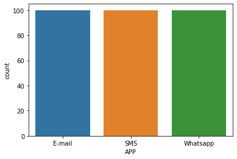

```python
sns.countplot(x="APP", data=dummyDataGriefbot)
```